# JASP for Bayesian analyses with default priors

[Ihnwhi Heo](https://ihnwhiheo.github.io/), [Duco Veen](https://www.ducoveen.com/), and [Rens van de Schoot](https://www.rensvandeschoot.com/)

Department of Methodology and Statistics, Utrecht University

Last modified: 15 July 2020

Welcome!

This tutorial illustrates how to perform Bayesian analyses in [JASP](https://jasp-stats.org/) (JASP Team, 2020) with default priors for starters. We deal with basic procedures to do Bayesian statistics and explain ways to interpret core results. In each analytic option, a brief comparison between Bayesian and frequentist statistics is presented. After the tutorial, we expect readers can perform correlation analysis, multiple linear regression, t-test, and one-way analysis of variance, all from a Bayesian perspective, and understand the logic of Bayesian statistics.

For readers who need a comprehensive understanding of what the JASP is, how to install it, how to manage and explore data, and how to interpret the statistical analyses from a frequentist perspective, we recommend reading [JASP for beginners](https://www.rensvandeschoot.com/tutorials/jasp-for-beginners/). The current tutorial assumes that readers are prepared for the fundamentals of JASP.

Throughout this tutorial, we will use a dataset (`popular_regr_1`) from [van de Schoot, van der Velden, Boom, and Brugman (2010)](https://github.com/Rensvandeschoot/Tutorials/raw/master/JASP%20for%20Bayes%20with%20default%20priors/Can%20at-risk%20young%20adolescents%20be%20popular%20and%20anti-social.pdf). For more information on the sample, instruments, methodology, and research context, we refer interested readers to the paper (see references).

Since we continuously improve the tutorials, let us know if you discover mistakes, or if you have additional resources we can refer to. The source code is available via [Github](https://github.com/Rensvandeschoot/Tutorials). If you want to be the first to be informed about updates, follow Rens on [Twitter](https://twitter.com/RensvdSchoot).

Let’s get started!

## I. We go together with data

- Statistical analysis always goes along with data.
- To download the dataset that we will use (`popular_regr_1`), click [here](https://github.com/Rensvandeschoot/Tutorials/raw/master/JASP%20for%20Bayes%20with%20default%20priors/popular_regr_1.sav).
- With several mouse clicks, we can easily load the data. JASP offers three ways of loading data: from your computer, the in-built data library, or the [Open Science Framework](https://osf.io/).
- We expect you are familiar with loading the data.
  - If not, please go to [JASP for beginners](https://www.rensvandeschoot.com/tutorials/jasp-for-beginners/) and see how to load the data.

## III. Time to perform Bayesian analyses

- We assume that all the assumptions required for subsequent analyses are satisfied.
- In each analysis, we start by providing a brief comparison between the frequentist and the Bayesian approach for the chosen analysis. The procedures to perform the Bayesian analysis follows the comparison. Then, you encounter the interpretation of results.

### 1. Correlation analysis

- When you are interested in investigating the strength of the relationship between two variables, correlation analysis can be an option.
  - In frequentist statistics, the focus is to examine whether the correlation coefficient is significantly different from 0 or not. The significance level is usually set to .05. If a p-value is lower than the significance level, the null hypothesis that the correlation coefficient between two variables is 0 is rejected. The alternative hypothesis is that the correlation coefficient is not equal to 0.
  - In Bayesian statistics, the null hypothesis postulates that the correlation coefficient between the two variables is 0. In other words, two variables are not correlated. The alternative hypothesis, however, states that the correlation coefficient exists. That is, two variables are correlated.
- Between the null and the alternative hypothesis, Bayesian statistics quantifies the relative support toward each hypothesis from observed data. The Bayes factor shows this quantification. In JASP, the default Bayes factor is $BF_{10}$. This value means how much the observed data relatively supports the alternative hypothesis ($H_1$) than the null hypothesis ($H_0$).
- For a better grasp, let’s examine whether two variables in the dataset, covert and overt, are correlated.
- Go to the top bar -> Click Regression -> Click Bayesian Correlation under Bayesian section
- Foremost, we will set a seed to guarantee that results are reproducible. Any numbers are possible. This tutorial uses a seed of 123.
- Click Options in the control panel -> Check Set seed under Repeatability -> Type 123
- In our example, move covert and overt under the Variables section. Next, check Report Bayes factors and Credible intervals under Additional Options in the control panel.

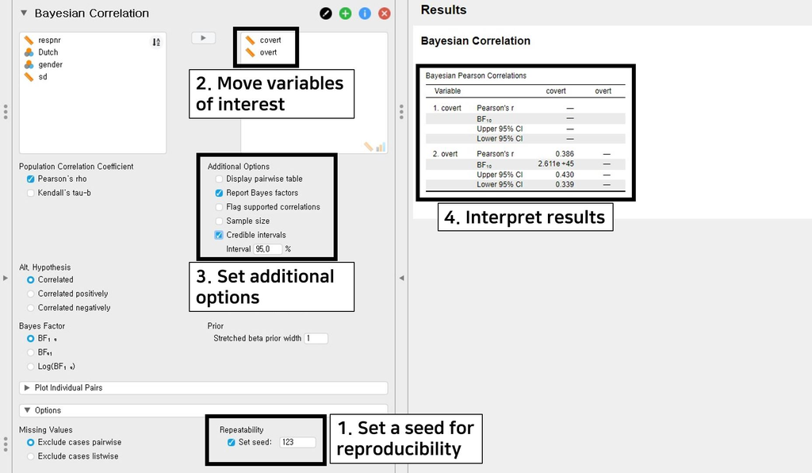

- The correlation coefficient between covert and overt is 0.386 and the $BF_{10}$ is 2.611e+45. The number 2.611e+45 equals $2.611 × 10^{45}$. This means that the support in the observed data is about $2.611 × 10^{45}$ times larger for the alternative hypothesis (i.e., covert and overt are correlated) than for the null hypothesis (i.e., covert and overt are not correlated).
- The upper and lower limit of 95% credible interval is 0.430 and 0.339. We can check that 0 is not included in the 95% credible interval. It means that there is a 95% probability that the correlation coefficient between covert and overt lies in the population within the corresponding interval. Thus, it is fairly sure that covert and overt are correlated.
- Notice that the Bayesian statistics is not concerned with rejecting or not rejecting the null hypothesis. Rather, it is keen on how much the observed data supports the alternative or the null hypothesis.

### 2. Multiple linear regression

- Regression analysis is performed when you are interested in predicting outcomes of a continuous dependent variable with multiple continuous or categorical independent variables.
  - In the frequentist framework, we examine whether the regression coefficient is significantly different from 0. If the p-value is lower than the significance level, the null hypothesis that the regression coefficient is 0 is rejected. The alternative hypothesis is that the regression coefficient is not equal to 0.
  - In the Bayesian framework, the null hypothesis states that the regression coefficient of the independent variables is 0. In other words, the independent variables do not predict the dependent variables. The alternative hypothesis states that the regression coefficient exists. That is, the independent variables predict the dependent variables.
- We will use sd as the dependent variable and covert and overt as the independent variables.
- Go to the top bar -> Click Regression -> Click Linear Regression under Bayesian section
- Let’s first set a seed of 123 for replicable results.
- Click Advanced Options in the control panel -> Check Set seed under Repeatability -> Type 123
- For our purposes, move sd under the Dependent Variable section and covert and overt under the Covariates section. Then, check the Posterior summary under Output in the control panel.

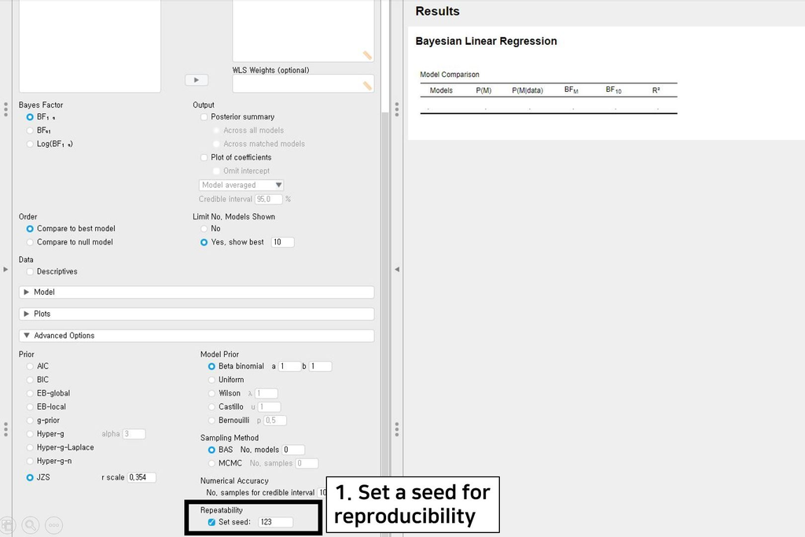

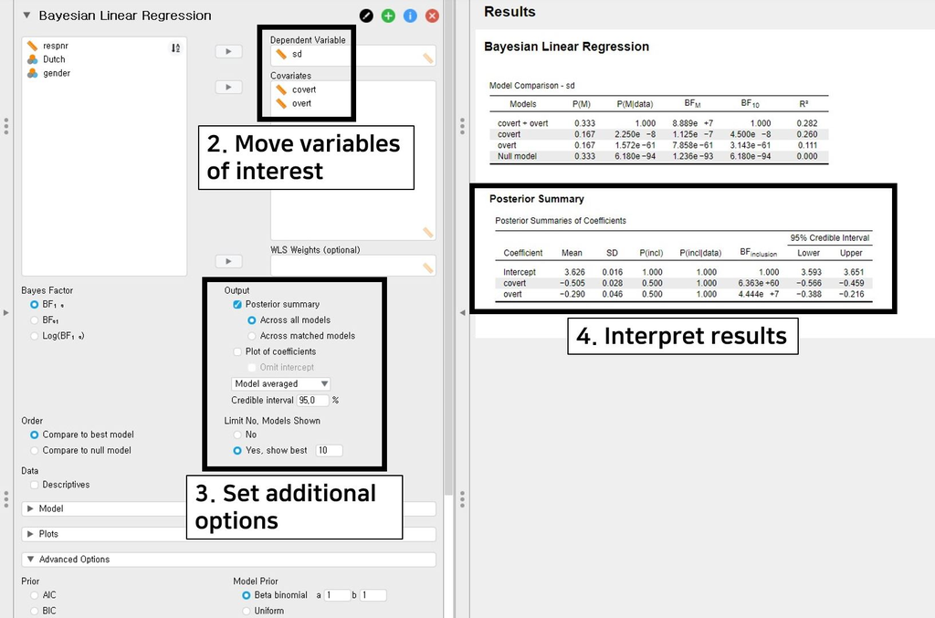

- To interpret the results, look at the table under Posterior Summary in the output panel. As the title ‘Posterior Summary’ says, statistical inferences in Bayesian statistics are focused on the posterior distribution. The posterior summary shows the summary of regression coefficients after taking into account the default prior and the likelihood of data. The Mean and the SD refer to the posterior mean and the posterior standard deviation.
  - The posterior mean of the regression coefficient of covert is -0.505. The 95% credible interval of [-0.566, -0.459] indicates that there is a 95% probability that the regression coefficient of covert lies in the population within the corresponding credible interval. Also, the 95% credible interval does not include 0, so it is fairly sure that there is an effect of covert in predicting sd.
  - The posterior mean of the regression coefficient of overt, on the other hand, is -0.290. According to the 95% credible interval of [-0.388, -0.216], we are 95% sure that the regression coefficient of overt lies within the corresponding interval in the population. Furthermore, 0 is not included in the 95% credible. Thus, there is fair evidence that overt predicts sd.
- Again, we can notice that the Bayesian framework does not concern with rejecting or not rejecting the null hypothesis. This is one of the important characteristics that the Bayesian statistics has!

### 3. t-test

- If you are interested in investigating whether the means of certain variables between the two groups are different from each other, a t-test can be an option.
  - From a frequentist perspective, the focus is to investigate whether the means between the two groups are significantly different. If the p-value is lower than the significance level, the null hypothesis that the mean difference between the two groups is equal to 0 is rejected. The alternative hypothesis postulates that the mean difference is significantly different from 0.
  - From a Bayesian perspective, the null hypothesis states that there is no mean difference between the two groups. The alternative hypothesis, on the other hand, is that there is a mean difference between the two groups.
- Let’s examine whether the means of covert between two groups in the Dutch variable are different.
- Go to the top bar -> Click T-Tests -> Click Independent Samples T-Test under Bayesian section
- Because we assumed that all assumptions are met, we will use the Student t-test. For the Student t-test, we do not need to set seed! Thus, we go directly to the next step.
  - If you use the Mann-Whitney U test since the assumptions of the independent samples t-test are violated, it is possible to set seed to have a replicable output.
- Move the covert variable under the Variables section and the Dutch variable under the Grouping Variable section.

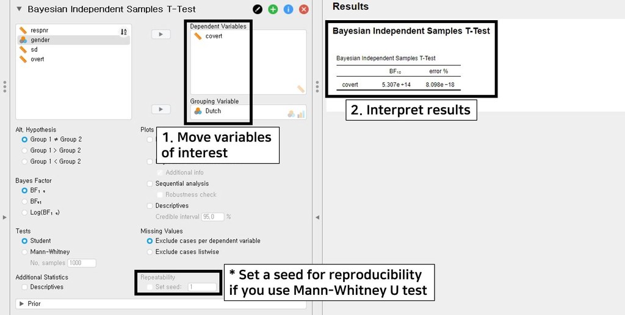

- The table under the Bayesian Independent Samples T-Test provides the output. The number 5.307e+14 of $BF_{10}$ is equal to $5.307 × 10^{14}$. This means that the observed data support $5.307 × 10^{14}$ times more for the alternative hypothesis (i.e., there is a mean difference of covert between the two groups of the Dutch variable) than for the null hypothesis (i.e., A mean difference of covert between the two groups of the Dutch variable does not exist).
- The error % (error percentage) is 8.098e-18, which is $8.098 × 10^{-18}$. Because the error percentage is low enough, it indicates that the numerical results are robust.

### 4. One-way analysis of variance

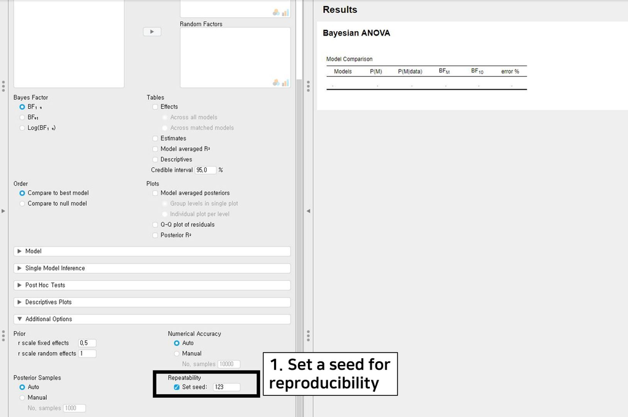

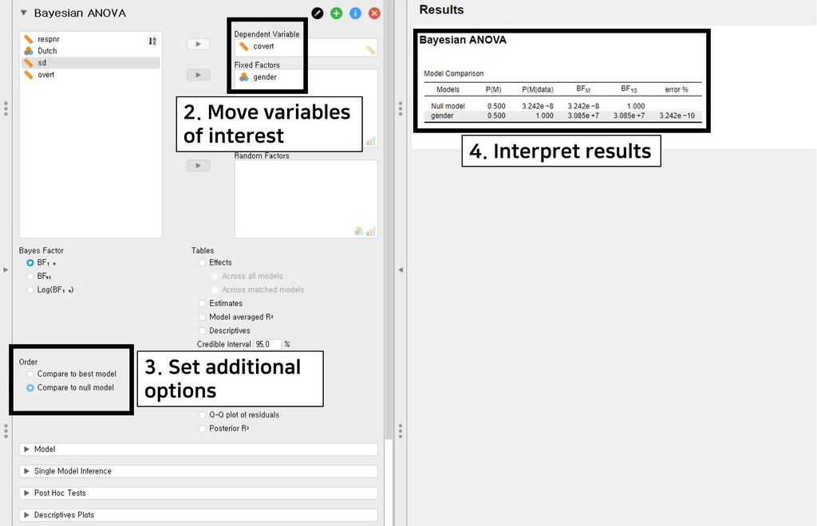

- Let’s take a look at the table under the Bayesian ANOVA in the output panel. The Null model only contains the grand mean. The gender model (denoted as gender in the first column) adds an effect of the gender variable to the null model. Consequently, we have to look at the ‘gender’ model row.
- The value 3.085e+7 of $BF_{10}$ equals $3.085 × 10^{7}$. This implies that the support is $3.085 × 10^{7}$ times larger for the alternative hypothesis (i.e., there exists mean differences of covert across gender groups) than for the null hypothesis (i.e., mean differences of covert do not exist across gender groups).
- As explained in the t-test part, the error percentage indicates the numerical robustness of results. The error percentage of 3.242e-10 is equal to $3.242 × 10^{-10}$. This value is lower enough to show that the results are stable.

## IV. Epilogue

- Congratulations! You have reached the finish line of this tutorial. We hope you enjoyed it.
- It should be noted that we performed the Bayesian analysis with the default priors. However, it is possible to use the informative priors depending on, for instance, previous literature or expert knowledge.
- We also dealt with simple but core steps excluding other advanced options. We want to emphasize that there are more interesting things to explain in doing Bayesian analyses.
- Therefore, we strongly recommend you to read our next tutorial JASP for Bayesian analyses with informative priors. It deals with Bayesian statistics more in-depth. See you soon!

### References

JASP Team (2020). JASP (Version 0.12.2)[Computer software].

van de Schoot, R., & Depaoli, S. (2014). Bayesian analyses: Where to start and what to report. The European Health Psychologist, 16(2), 75-84.

van de Schoot, R., Kaplan, D., Denissen, J., Asendorpf, J. B., Neyer, F. J., & Van Aken, M. A. (2014). A gentle introduction to Bayesian analysis: Applications to developmental research. Child development, 85(3), 842-860. https://doi.org/10.1111/cdev.12169

van de Schoot, R., van der Velden, F., Boom, J., & Brugman, D. (2010). Can at-risk young adolescents be popular and anti-social? Sociometric status groups, anti-social behaviour, gender and ethnic background. Journal of adolescence, 33(5), 583-592. https://doi.org/10.1016/j.adolescence.2009.12.004